### Vẽ biểu đồ tương quan giữa các biến số exposures

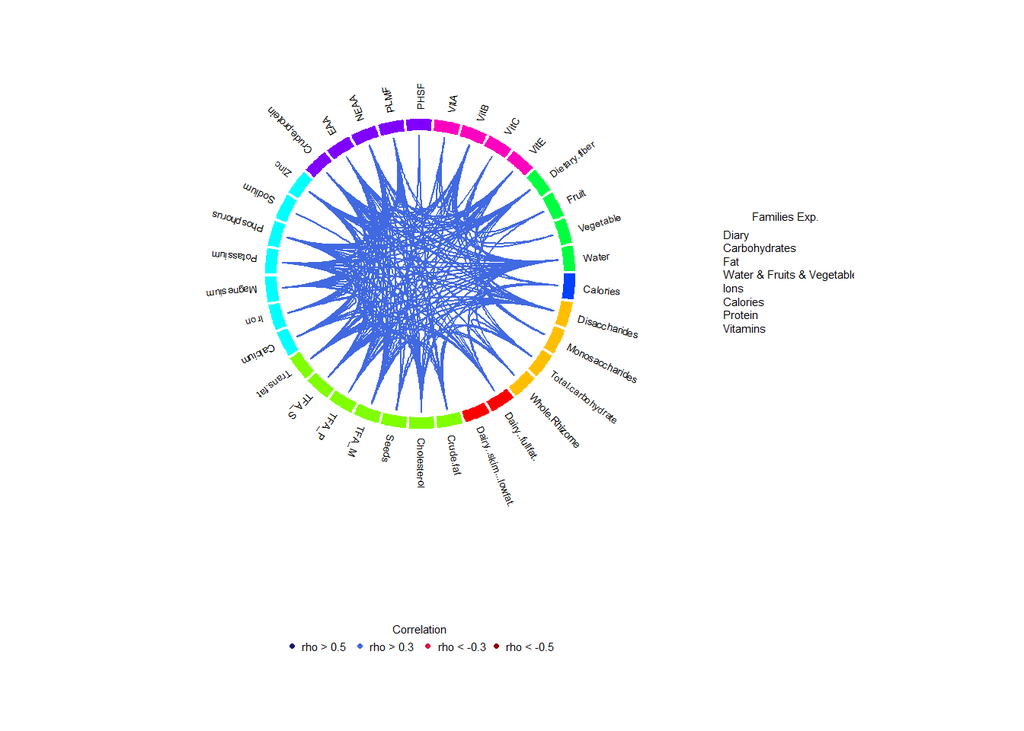

```r
plotCorrelation(inre_exp_c, type = "circos")
```

```r
# corrplot(cor_matrix, method="square")
```

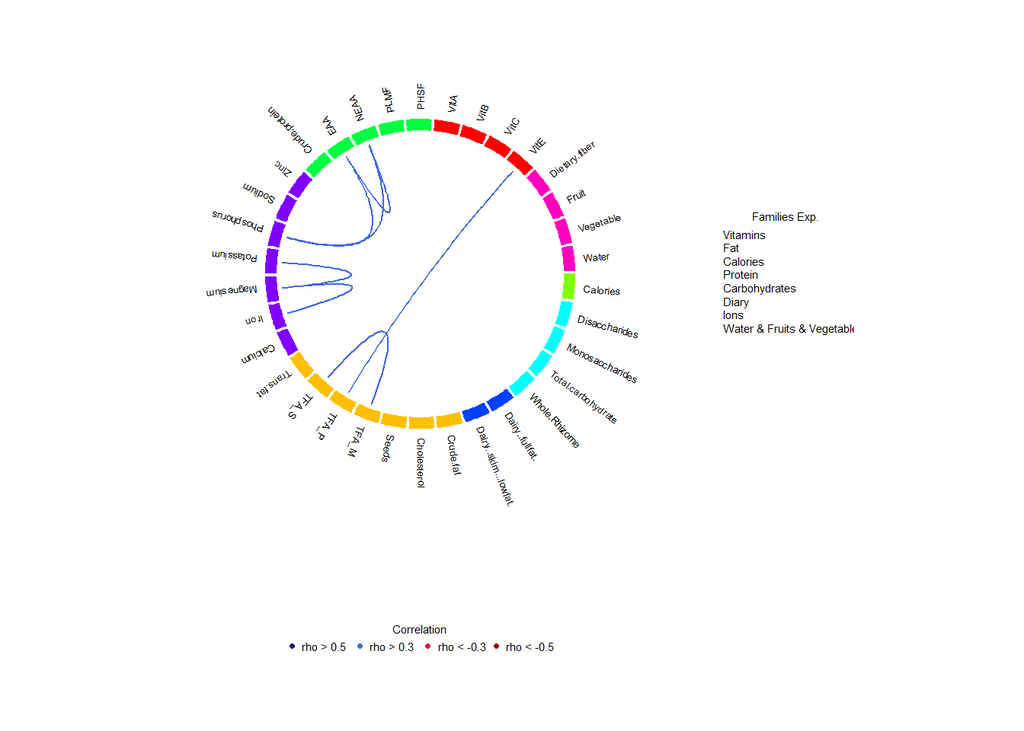

```r
# Tạo bản sao object gốc
inre_exp_c_filtered <- inre_exp_c

# Lấy ma trận tương quan
cor_mat <- assayDataElement(inre_exp_c_filtered, "corr")

# Chỉ giữ các giá trị |r| >= 0.9
cor_mat[abs(cor_mat) < 0.9] <- 0  # hoặc NA nếu muốn bỏ hẳn các cạnh

# Gán lại vào object
assayDataElement(inre_exp_c_filtered, "corr") <- cor_mat

# Vẽ biểu đồ circos với các kết nối >=0.9
plotCorrelation(
  inre_exp_c_filtered,
  type = "circos",
)
```

- Chú ý cách trích xuất corr matrix từ inre_exp_c object bằng assayDataElement
- Các điểm dữ liệu < 0.9 quy bằng 0

### Exposome PCA

```r
exp_pca <- pca(inre_exp_s, pca = TRUE)
exp_pca_data <- assayDataElement(exp_pca, "exp")
exp_pca
```

```
## Object of class 'ExposomePCA' (storageMode: environment)
##  . num. prin. components: 34
##  . assayData: 34 exposures 237 samples
##     . element names: exp
##     . exposures: Calcium, ..., Whole.Rhizome
##     . samples: 100, ..., w0093
##  . phenoData: 237 samples 5 phenotypes
##     . samples: 100, ..., w0093
##     . phenotypes: sex, ..., calories.kcal.
##  . featureData: 34 exposures 7 explanations
##     . exposures: Calcium, ..., Whole.Rhizome
##     . descriptions: Family, ..., .imp
```

### Trực quan hóa PCA

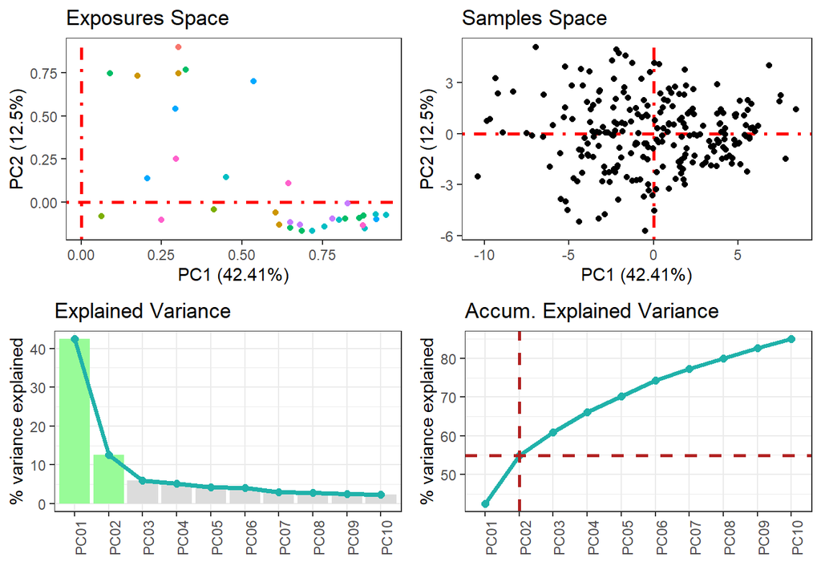

```r
plotPCA(exp_pca, set = "all")
```

**Giải thích biểu đồ** - Top-left: Exposure space showing each exposures in the first two principal components. Exposures are coloured by family - Top-right: Samples space projected in same two first principal components - Bottom-left: Proportion of explained variance for the first ten principal components - Bottom-right: Cumulative proportion of explained variance for the first ten principal components.